# Using Linear Regression to predict Poverty among elderly people in the American Midwest

msalauddin

September 11, 2020

The dataset contains 16 columns with information on the population and other factors of 437 counties in the American Midwest. Variable names are self-explanatory with those beginning with a "pop" prefix being numbers of population and those with a "per" prefix being percentages of the total population. I am including new variables called "popcollege" and "popprof". These are the population in each county with a college degree, and the population with a professional job. Using the "popchild" and "popadult" variables I am calculating a new variable "ratioca" which will be the ratio of children to adults in each county's population. Using the "inmetro" variable, I am subdividing the full data set to create two smaller data frames which include only rural and metropolitan counties, respectively. Finally, using a random seed I am taking a random sample of 60 counties from the rural poverty dataset and 30 counties from the metro poverty dataset.

Set the working directory and loading the data onto R for analysis.

```r
### pre-processing ######
#install.packages("data.table")
library(corrplot)
setwd("D:/USF/Semester 2/Qmb")
library(readxl)
popdata=read_excel("6304 Regression Project Data.xlsx")
popdata$popcollege = (popdata$percollege*popdata$poptotal)/100
popdata$popprof = (popdata$perprof*popdata$poptotal)/100
popdata$ratioca = (popdata$popchild/popdata$popadult)
popdata$popchildpoverty = (popdata$perchildpoverty*popdata$popchild)/100
##subset
metro = subset(popdata, inmetro == 1)
rural = subset(popdata, inmetro == 0)
##Random seed
set.seed(93827161)
some.rural.poverty = rural[sample(1:nrow(rural),60,replace=FALSE),]
some.metro.poverty = metro[sample(1:nrow(metro),30,replace=FALSE),]
```

Lets view the data to understand what it looks like

```r
head(popdata)
```

```
## # A tibble: 6 x 20
##      ID county state  area poptotal popdensity popwhite popblack popasian
##   <dbl> <chr>  <chr> <dbl>    <dbl>      <dbl>    <dbl>    <dbl>    <dbl>
## 1     1 ADAMS  IL     857.    66090       77.2    63917     1702      249
## 2     2 ALEXA~ IL     236.    10626       45.0     7054     3496       48
## 3     3 BOND   IL     380.    14991       39.4    14477      429       16
## 4     4 BOONE  IL     281.    30806      110.     29344      127      150
## 5     5 BROWN  IL     306.     5836       19.1     5264      547        5
## 6     6 BUREAU IL     869.    35688       41.1    35157       50      195
## # ... with 11 more variables: popadult <dbl>, popchild <dbl>, percollege <dbl>,
## #   perprof <dbl>, perchildpoverty <dbl>, perelderlypoverty <dbl>,
## #   inmetro <dbl>, popcollege <dbl>, popprof <dbl>, ratioca <dbl>,
## #   popchildpoverty <dbl>
```

## Analyzing the data, plotting to check correlation between variables with a correlation matrix

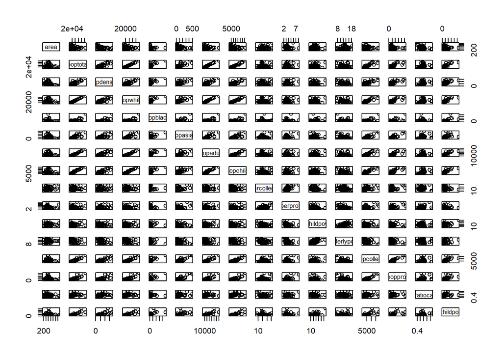

```r
continuous.rural.poverty = subset(some.rural.poverty,select=c("area","poptotal","popdensity","popwhite","popblack","popasian","popadult","popchild","percollege","perprof","perchildpoverty","perelderlypoverty","popcollege","popprof","ratioca","popchildpoverty"))
plot(continuous.rural.poverty)
```

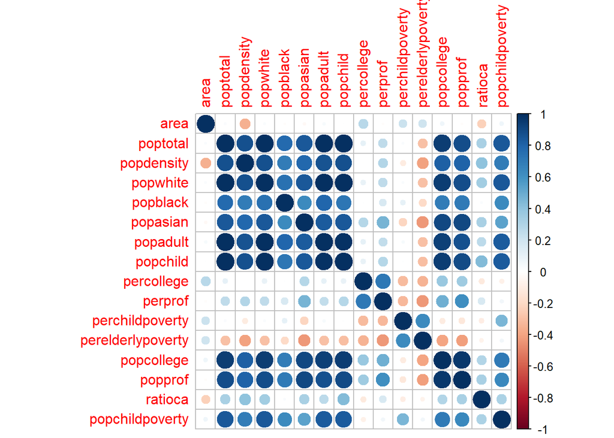

```r
xx=cor(continuous.rural.poverty)
corrplot(xx,method="circle")
```

We can see that correlation exits between poptotal and popchild, poptotal and popdensity, popcollege, popchildpoverty and so on.

```r
regout1=lm(perelderlypoverty~.-ID-county-state,data=some.rural.poverty)
summary(regout1)
```

```
##
## Call:
## lm(formula = perelderlypoverty ~ . - ID - county - state, data = some.rural.poverty)
##
## Residuals:
##     Min      1Q  Median      3Q     Max
## -3.6834 -0.7881 -0.0655  0.9936  3.8881
##
## Coefficients: (2 not defined because of singularities)
##                   Estimate Std. Error t value Pr(>|t|)
## (Intercept)      3.0787348  6.4159153   0.480   0.6337
## area             0.0017233  0.0016083   1.072   0.2896
## poptotal        -0.0021941  0.0010328  -2.124   0.0392 *
## popdensity      -0.0097412  0.0213050  -0.457   0.6497
## popwhite         0.0013139  0.0009105   1.443   0.1559
## popblack         0.0012119  0.0010076   1.203   0.2353
## popasian         0.0036146  0.0064161   0.563   0.5760
## popadult         0.0012014  0.0009237   1.301   0.2000
## popchild                NA         NA      NA       NA
## percollege      -0.0699152  0.2859046  -0.245   0.8079
## perprof         -0.3893469  0.8438411  -0.461   0.6467
## perchildpoverty  0.1795608  0.0923500   1.944   0.0581 .
## inmetro                 NA         NA      NA       NA
## popcollege       0.0002372  0.0011014   0.215   0.8305
## popprof          0.0003850  0.0027135   0.142   0.8878
## ratioca         16.8244793 10.0155876   1.680   0.0999 .
## popchildpoverty  0.0004816  0.0006185   0.779   0.4403
## ---
## Signif. codes:  0 '***' 0.001 '**' 0.01 '*' 0.05 '.' 0.1 ' ' 1
##
## Residual standard error: 1.736 on 45 degrees of freedom
## Multiple R-squared:  0.605,  Adjusted R-squared:  0.4821
## F-statistic: 4.922 on 14 and 45 DF,  p-value: 2.079e-05
```

```r
regout2=lm(perelderlypoverty~perchildpoverty+popchildpoverty+area+poptotal+ratioca,data=some.rural.poverty)
summary(regout2)
```

```
##
## Call:
## lm(formula = perelderlypoverty ~ perchildpoverty + popchildpoverty +
##     area + poptotal + ratioca, data = some.rural.poverty)
##
## Residuals:
##     Min      1Q  Median      3Q     Max
## -4.0314 -1.0023 -0.1732  1.3074  4.0385
##
## Coefficients:
##                   Estimate Std. Error t value Pr(>|t|)
## (Intercept)      7.085e+00  2.442e+00   2.902  0.00536 **
## perchildpoverty  2.313e-01  7.469e-02   3.097  0.00310 **
## popchildpoverty  2.854e-04  4.259e-04   0.670  0.50566
## area             1.138e-03  9.449e-04   1.204  0.23379
## poptotal        -6.175e-05  3.159e-05  -1.954  0.05584 .
## ratioca          3.481e+00  3.103e+00   1.122  0.26692
## ---
## Signif. codes:  0 '***' 0.001 '**' 0.01 '*' 0.05 '.' 0.1 ' ' 1
##
## Residual standard error: 1.744 on 54 degrees of freedom
## Multiple R-squared:  0.5212, Adjusted R-squared:  0.4769
## F-statistic: 11.76 on 5 and 54 DF,  p-value: 1.031e-07
```

After adding and removing a few independent variables, I came up with the final model which outperformed the previous two, with an increased DF and better p-value, along with a good adusted R-squared score.

```r
regout3=lm(perelderlypoverty~perchildpoverty+perprof+popdensity+popcollege,data=some.rural.poverty)
summary(regout3)
```

```
##
## Call:
## lm(formula = perelderlypoverty ~ perchildpoverty + perprof +
##     popdensity + popcollege, data = some.rural.poverty)
##
## Residuals:
##     Min      1Q  Median      3Q     Max
## -4.1140 -0.7701 -0.0915  1.2380  3.7887
##
## Coefficients:
##                   Estimate Std. Error t value Pr(>|t|)
## (Intercept)      1.052e+01  1.316e+00   7.988 9.12e-11 ***
## perchildpoverty  2.388e-01  4.247e-02   5.623 6.49e-07 ***
## perprof         -3.376e-01  2.547e-01  -1.325    0.191
## popdensity      -1.500e-02  1.036e-02  -1.448    0.153
## popcollege      -5.364e-05  1.146e-04  -0.468    0.641
## ---
## Signif. codes:  0 '***' 0.001 '**' 0.01 '*' 0.05 '.' 0.1 ' ' 1
##
## Residual standard error: 1.7 on 55 degrees of freedom
## Multiple R-squared:  0.537,  Adjusted R-squared:  0.5033
## F-statistic: 15.95 on 4 and 55 DF,  p-value: 1.002e-08
```

Potting the final regression equation to check its conformity to the LINE assumptions of regression

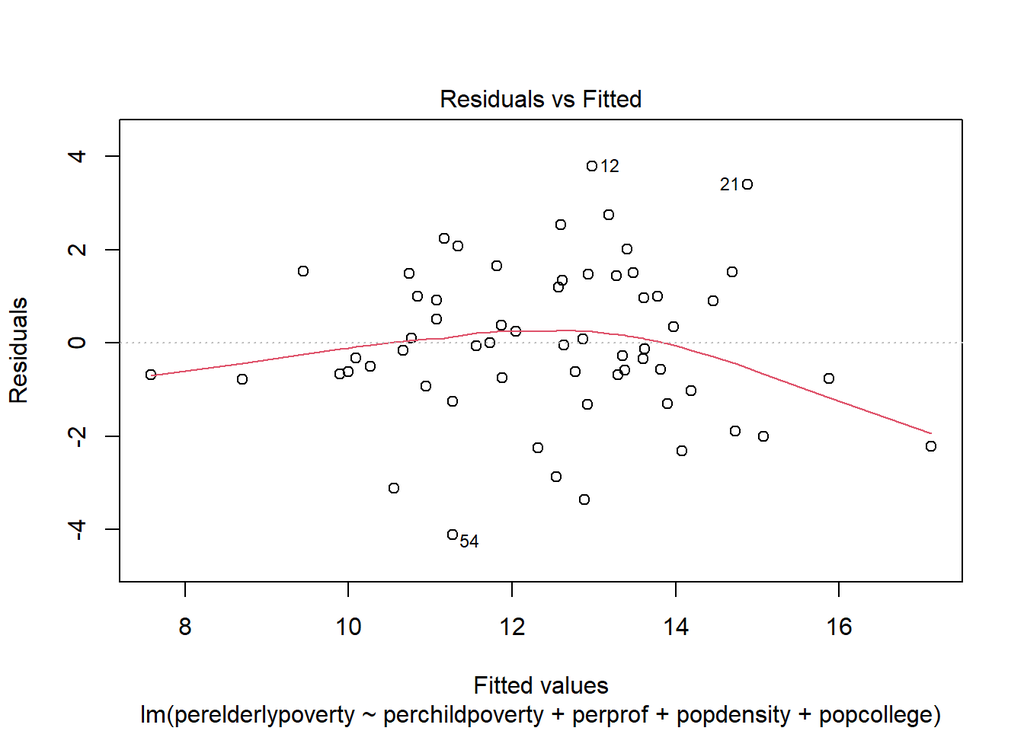

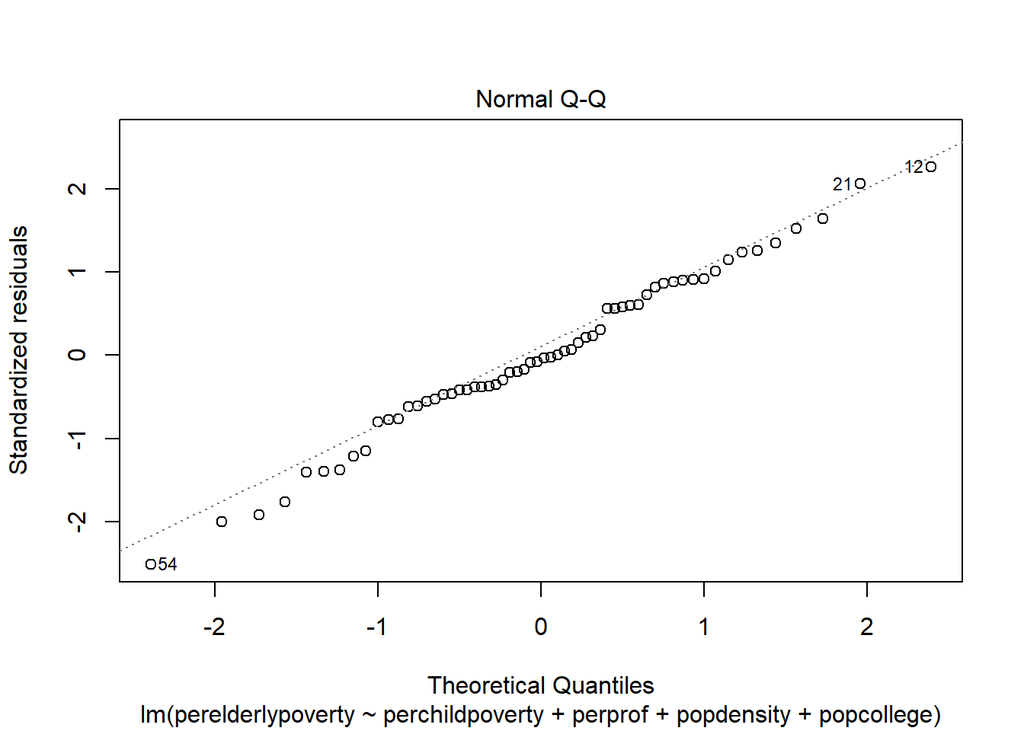

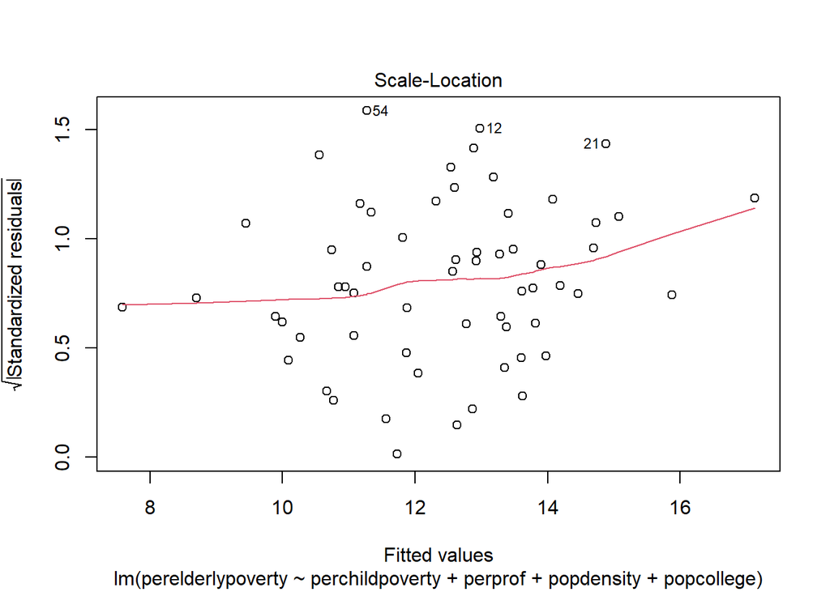

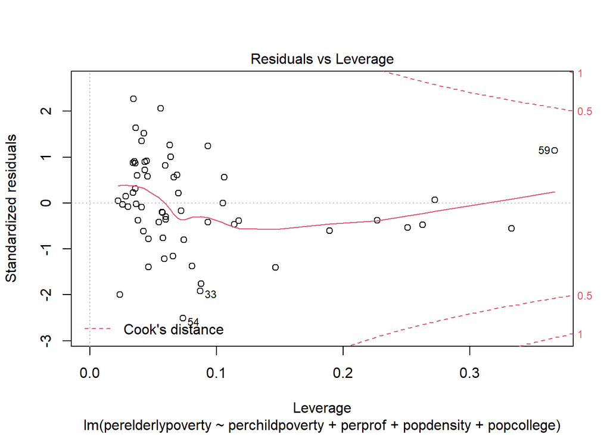

Figure 1

```r
plot(regout3)
```

From the Residuals vs Fitted plot we can see that the model violates linearity assumption.

From the qqplot we can assume that the model is normal.

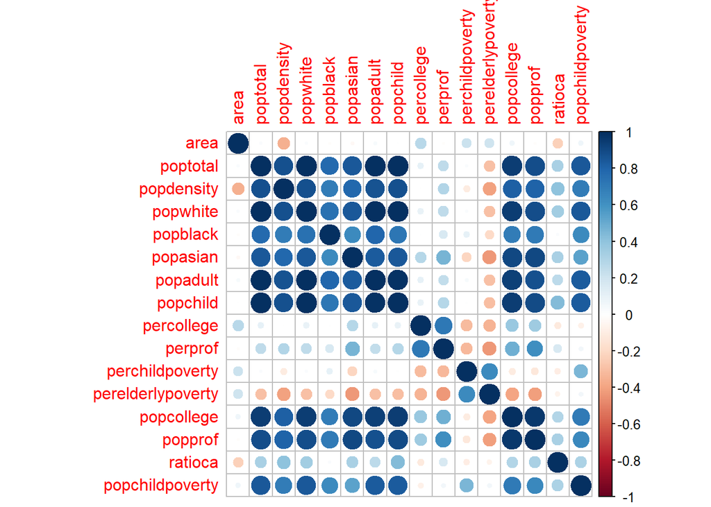

```r
#putting a correlation matrix into object
#install.packages('corrplot')
#library(corrplot)
xx=cor(continuous.rural.poverty)
corrplot(xx,method="circle")
```

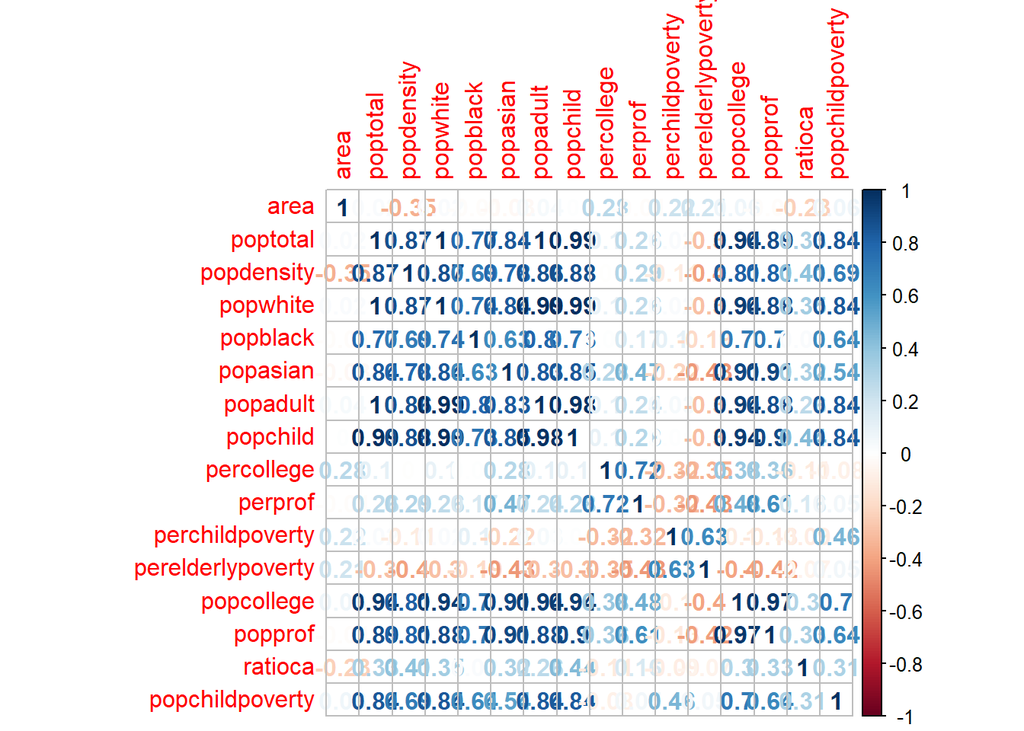

```r
corrplot(xx,method="number")
```

Subsetting few columns to find correlation

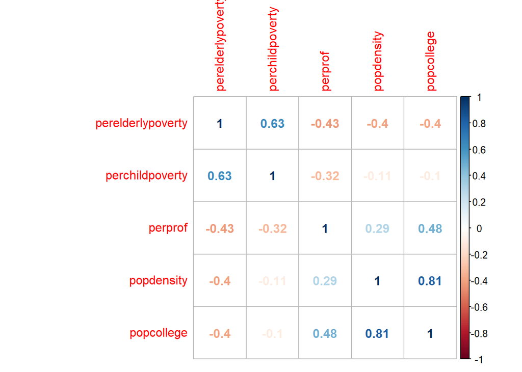

```r
d1=subset(some.rural.poverty,select=c("perelderlypoverty","perchildpoverty","perprof","popdensity","popcollege","popprof"))
d2=subset(some.rural.poverty,select=c("perelderlypoverty","perchildpoverty","perprof","popdensity","popcollege"))

yy=cor(d2)
corrplot(yy,method="number")
```

The above plot was used to check correlation between the subsetted variables.

```r
#Correlation matrix with p values.
#install.packages('Hmisc')
#library(Hmisc)
#xx=rcorr(as.matrix(d2))
#xx
```

### Using Variation Inflation Factors (VIF) to check if multicollinearity exits in the best fit model.

Multicollinearity occurs when independent variables in a regression model are correlated.

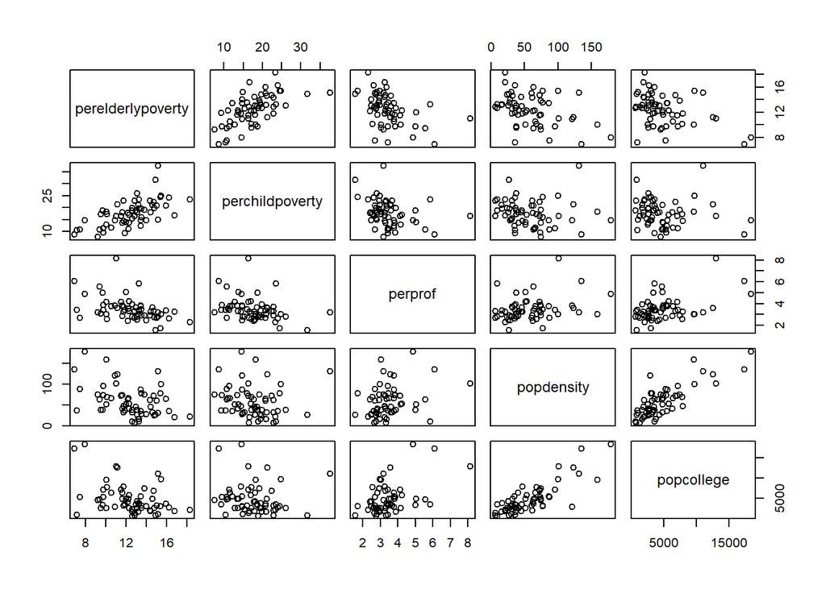

```r
plot(d2)
```

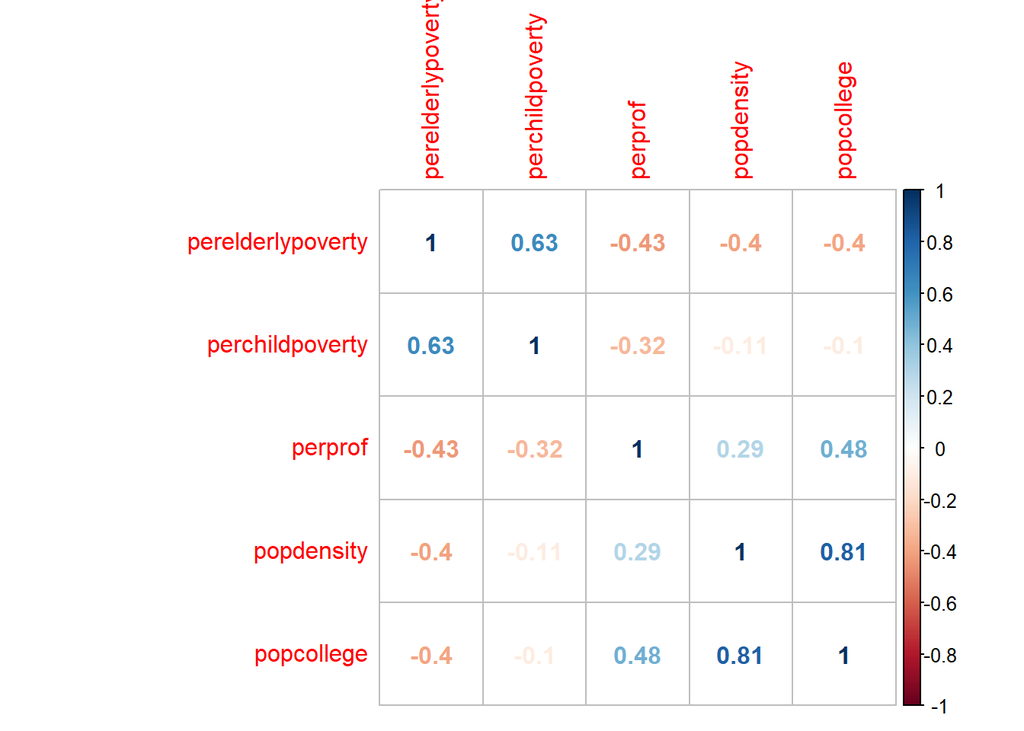

```r
xx=cor(d2)
corrplot(xx,method="number")
```

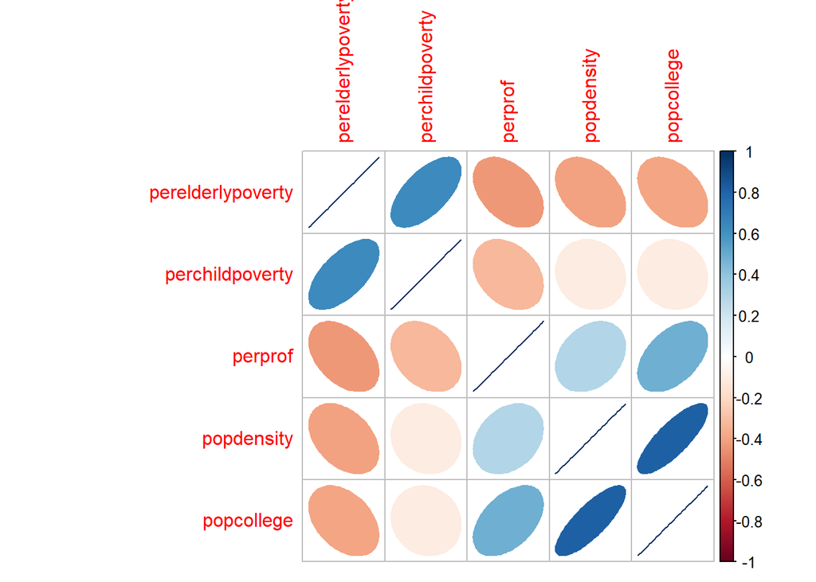

```r
corrplot(xx,method="ellipse")
```

```r
library(car)
vif(regout3)
```

```
## perchildpoverty         perprof      popdensity      popcollege
##        1.131683        1.510722        3.066577        3.664088
```

### Determining if any of the counties in "some.rural.poverty" data set have an outsized leverage in influencing the best fit model.

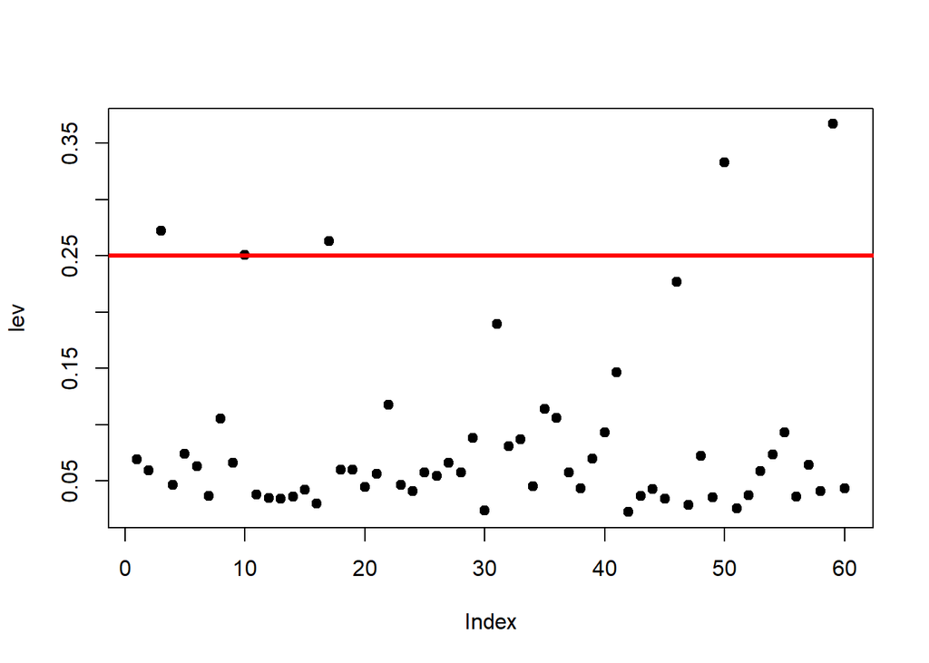

```r
#boxplot(some.rural.poverty$perelderlypoverty)
#max(some.rural.poverty$perelderlypoverty)
#which(some.rural.poverty$perelderlypoverty==18.27736)

#Leverage of Points
lev=hat(model.matrix(regout3))
plot(lev,pch=19)
abline(3*mean(lev),0,col="red",lwd=3)
```

```r
some.rural.poverty[lev>(3*mean(lev)),]
```

```
## # A tibble: 5 x 20
##      ID county state  area poptotal popdensity popwhite popblack popasian
##   <dbl> <chr>  <chr> <dbl>    <dbl>      <dbl>    <dbl>    <dbl>    <dbl>
## 1   123 FAYET~ IN     215.    26015       121.    25462      435       69
## 2   148 LA PO~ IN     598.   107066       179.    96286     9580      431
## 3   430 WALWO~ WI     555.    75000       135.    72747      454      494
## 4   350 SCIOTO OH     612.    80327       131.    77253     2458      126
## 5    15 COLES  IL     508.    51644       102.    50177      925      341
## # ... with 11 more variables: popadult <dbl>, popchild <dbl>, percollege <dbl>,
## #   perprof <dbl>, perchildpoverty <dbl>, perelderlypoverty <dbl>,
## #   inmetro <dbl>, popcollege <dbl>, popprof <dbl>, ratioca <dbl>,
## #   popchildpoverty <dbl>
```

```r
#Leverage of Points
#lev=hat(model.matrix(regout3))
#plot(lev,pch=19)
#abline(3*mean(lev),0,col="red",lwd=3)
#some.rural.poverty[lev>(3*mean(lev)),]
```

The counties and states above, have an outsized leverage in influencing my best fit model

### Assessing how well my best fit model predicts "perelderlypoverty" when applied to the "some.metro.poverty" data frame

```r
predict(regout3,some.metro.poverty,interval="confidence")
```

```
##            fit         lwr       upr
## 1    5.5276971    2.843899  8.211496
## 2    2.5301778   -3.134210  8.194565
## 3   -6.4400343  -18.139419  5.259351
## 4    5.0723315    2.206721  7.937942
## 5    9.4421501    8.349735 10.534566
## 6   13.0751976   11.821291 14.329104
## 7   11.2688859   10.250740 12.287032
## 8    7.5797333    3.262061 11.897405
## 9   -0.0704781   -8.946807  8.805851
## 10   2.2190998   -4.213918  8.652117
## 11   8.4627646    6.007678 10.917851
## 12   7.5331834    5.227290  9.839076
## 13   8.5119103    5.809252 11.214569
## 14   3.5743975   -2.885722 10.034517
```

[output cut: 16 more lines]

The percentage of elderly poverty is predicted to be 2.98% in Floyd, IN based on the independent variables used in regout3 (final regression equation). And, we are 95% confident that the percentage of perelderlypoverty would fall between -5.6227978 - 11.592168 %. In a similar way rest of the 29 data entries can be interpreted.